# Análise Preditiva de Incêndios Florestais no Estado do RJ

Carregando Bibliotecas:

```r
library(tidyverse)
library(reshape2)
library(ggplot2)
library(mice)
library(data.table)
library(ggmap)
library(Hmisc)
library(corrplot)
library(geosphere)
library(rattle)
library(caret)
library(maps)
library(mapdata)
library(caretEnsemble)
library(DT)
library(parallel)
library(doParallel)
```

# **Objetivos**

Está analise consiste na utilização de observações de queimadas e incêndios florestais feitas pelo INPE (Instituto Nacional de Pesquisas Espaciais) em conjunto com observações de estações meteorológicas convencionais do INMET( Instituto Nacional de Meteorologia) na tentativa de obter correlações entre as queimadas e incêndios florestais e as condições meteorológicas de forma a predizer quando ocorrerá um evento.

# **Base de dados**

## **Conjunto de dados: Focos**

Foi utilizada um série temporal extraída do Banco de Dados de queimadas do INPE (https://prodwww-queimadas.dgi.inpe.br/bdqueimadas) no formato CSV contendo dados do dia 01/01/2010 até 31/12/2016 com as seguintes colunas:

- DataHora - Data e hora da detecção do foco
- Satelite - Nome do satélite de referência
- Pais - País da detecção
- Estado - estado da detecção
- Municipi - município da detecção
- Bioma - bioma da detecção
- DiaSemCh - A quantos dias a referida área está sem chuvas
- Precipit - Precipitação no momento da detecção
- RiscoFog - Risco de Fogo calculado para a área
- Latitude - Latitude do foco
- Longitud - Longitude do foco
- AreaIndu - Determina se a área do foco é industrial
- FRP - Potência Radiativa do Fogo

O Dataset possui alguns focos duplicados, o que se deve ao fato de vários satélites detectarem o mesmo foco de queimada. Dimensões do conjunto de dados - 8.618.991 linhas e 13 colunas

```r
load(file = "./dados/focos(bruto).RData")
summary(focos)
```

```
      DataHora                        Satelite               Estado
   Min.   :2010-01-01 01:21:19   NPP_375  :2179720   Mato Grosso:1458491
   1st Qu.:2012-09-05 20:30:00   AQUA_M-T :1298271   Para       :1375685
   Median :2015-05-25 04:46:53   NPP      : 800944   Maranhao   :1197028
   Mean   :2014-05-24 06:48:19   GOES-12  : 667737   Tocantins  : 842952
   3rd Qu.:2015-12-12 16:26:44   TERRA_M-T: 625269   Piaui      : 588302
   Max.   :2016-12-31 23:00:00   NOAA-18  : 504016   Bahia      : 583981
                                 (Other)  :2543034   (Other)    :2572552
                 Municipio                  Bioma          DiasSemChuva
   Corumba            : 139875   Amazonia      :3518671   Min.   : -2.00
   Sao Felix do Xingu : 109370   Caatinga      : 562722   1st Qu.:  2.00
   Porto Velho        : 106089   Cerrado       :3717535   Median :  7.00
   Altamira           : 105715   Mata Atlantica: 564997   Mean   : 19.55
   Lagoa da Confusao  :  88226   Pampa         :  19805   3rd Qu.: 29.00
   Formoso do Araguaia:  67725   Pantanal      : 235223   Max.   :120.00
   (Other)            :8001991   NA's          :     38
    Precipitacao       RiscoFogo        Latitude         Longitude
   Min.   :  -2.00   Min.   :  0.0   Min.   :-33.671   Min.   :-73.99
   1st Qu.:   0.00   1st Qu.:  0.8   1st Qu.:-13.050   1st Qu.:-54.68
   Median :   3.10   Median :  1.0   Median : -9.683   Median :-49.38
   Mean   :  17.56   Mean   : 13.0   Mean   :-10.024   Mean   :-50.37
   3rd Qu.:  21.20   3rd Qu.:  1.0   3rd Qu.: -5.917   3rd Qu.:-45.42
   Max.   :1539.20   Max.   :777.7   Max.   :  5.230   Max.   :-34.80
```

## **Conjunto de dados: Meteorologia**

Foram utilizados dados de estações meteorológicas convencionais obtidos através do Banco de Dados Meteorológicos para Ensino e Pesquisa (http://www.inmet.gov.br/projetos/rede/pesquisa/) contendo uma série temporal do dia 01/01/2010 ao dia 31/12/2016.

- Estacao – Código da estação convencional
- Data – Data da medição
- Hora – Hora da medição
- TempBulboSeco – temperatura medida com termômetro de bulbo seco
- TempBulboUmido – temperatura medida com termômetro de bulbo úmido
- UmidadeRelativa – umidade relativa do ar
- PressaoAtmEstacao – pressão atmosférica no nível da estação
- VelocidadeVento – velocidade do vento no momento da medição
- Nebulosidade – nebulosidade no momento da medição
- Latitude – Latitude da estação
- Longitude – Longitude da estação

Dimensões do conjunto de dados – 1.781.719 linhas e 11 colunas

```r
load(file = "./dados/meteo(bruto).RData")
summary(meteo)
```

```
      Estacao           Data                 Hora        TempBulboSeco
   Min.   :82024   Min.   :2010-01-01   Min.   :   0.0   Min.   :-6.00
   1st Qu.:82693   1st Qu.:2011-08-25   1st Qu.:   0.0   1st Qu.:22.60
   Median :83270   Median :2013-04-25   Median :1200.0   Median :25.80
   Mean   :83158   Mean   :2013-05-15   Mean   : 977.2   Mean   :25.43
   3rd Qu.:83589   3rd Qu.:2015-01-22   3rd Qu.:1800.0   3rd Qu.:28.60
   Max.   :83997   Max.   :2016-12-31   Max.   :1800.0   Max.   :44.90
                                                         NA's   :14513
   TempBulboUmido   UmidadeRelativa PressaoAtmEstacao  VelocidadeVento
   Min.   :-4.60    Min.   :  8.0   Length:1781719     Min.   : 0.00
   1st Qu.:19.00    1st Qu.: 58.0   Class :character   1st Qu.: 0.70
   Median :21.80    Median : 73.0   Mode  :character   Median : 1.50
   Mean   :21.22    Mean   : 70.8                      Mean   : 1.82
   3rd Qu.:24.00    3rd Qu.: 86.0                      3rd Qu.: 3.00
   Max.   :37.80    Max.   :100.0                      Max.   :25.72
   NA's   :287610   NA's   :15983                      NA's   :160978
    Nebulosidade       Latitude        Longitude
   Min.   : 0.000   Min.   :-33.51   Min.   :-72.66
   1st Qu.: 2.500   1st Qu.:-20.03   1st Qu.:-51.13
   Median : 6.000   Median :-13.43   Median :-45.94
   Mean   : 5.508   Mean   :-13.86   Mean   :-46.85
   3rd Qu.: 9.000   3rd Qu.: -6.97   3rd Qu.:-41.48
   Max.   :12.500   Max.   :  2.82   Max.   :-34.86
   NA's   :9127
```

# **Pré-processamento**

## Seleção dos dados

O conjunto de dados Focos não utilizará as colunas “AreaIndu” e “FRP” pois as mesmas estão vazias e não utilizará também a coluna “Pais” já todos os dados se referem apenas ao Brasil.

O dois conjuntos serão filtrados para conterem somente os dados referentes ao estado do Rio de Janeiro. O conjunto focos será filtrado pela coluna Estado, a qual poderá ser removida justamente pois se tornará redundante. O conjunto meteo será filtrado através das estações 83738, 83049, 83743, 83718, 83698 e 83695 localizadas respectivamente em Resende, Paty do Alferes, Rio de janeiro, Cordeiro, Campos dos Goytacazes e Itaperuna, a localização das estações foi obtida através do site do INMET.

```r
focos_rj <- focos %>%
    filter(Estado == "Rio de Janeiro") %>%
    select(-Estado)

100-(dim(focos_rj)[1]/dim(focos)[1]*100)
```

```
  [1] 99.73055
```

A primeira filtragem do conjunto focos reduziu o número de observações de 8.618.991 para apenas 23.224, uma redução de 99.73% do dataset.

```r
meteo_rj <- meteo %>%
    filter(Estacao == 83049 | Estacao == 83738 | Estacao ==  83743 |
               Estacao == 83718 | Estacao == 83698 | Estacao == 83695) %>%
    mutate(mes = as.numeric(format(.[["Data"]], "%m")), ano = as.numeric(format(.[["Data"]], "%Y")))
100-(dim(meteo_rj)[1]/dim(meteo)[1]*100)
```

```
  [1] 97.61208
```

A primeira filtragem do conjunto meteo reduziu o número de observações de 1.781.719 para apenas 42.546, uma redução de 97.61% do dataset, além disso foram acrescentadas duas colunas, “mes” e “ano”.

## Qualidade e Limpeza dos dados

### Limpeza do conjunto de dados Meteo

#### Verificando as observações faltantes

```r
sapply(meteo_rj, function(x)(sum(is.na(x))))
```

```
            Estacao              Data              Hora     TempBulboSeco
                  0                 0                 0                63
     TempBulboUmido   UmidadeRelativa PressaoAtmEstacao   VelocidadeVento
               1746                46              7405              3791
       Nebulosidade          Latitude         Longitude               mes
                 46                 0                 0                 0
                ano
                  0
```

#### Checando a frequência das estações por ano

```r
freq_table <- xtabs(~ano+Estacao, data=meteo_rj) %>%
      t(.)
freq_table <- reshape(as.data.frame(freq_table), timevar = "ano", idvar = "Estacao", direction = "wide")
head(freq_table[which(freq_table == 0, arr.ind = TRUE)[,1],])
```

| Estacao | Freq.2010 | Freq.2011 | Freq.2012 | Freq.2013 | Freq.2014 | Freq.2015 | Freq.2016 |
| --- | --- | --- | --- | --- | --- | --- | --- |

Todas as estações tem dados para todos os anos.

#### Distribuição de Valores faltantes por ano

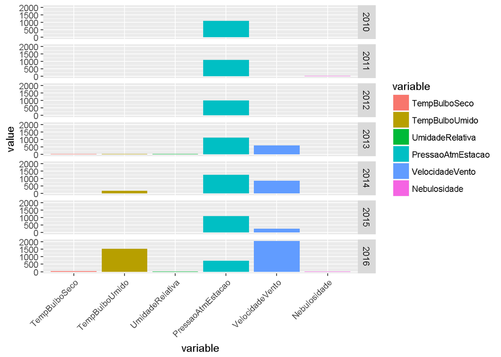

```r
aggregate(. ~ ano, data=meteo_rj, function(x) {sum(is.na(x))}, na.action = NULL) %>%
      melt(id.vars = "ano") %>%
      filter (value > 0) %>%
      ggplot(data = . , aes(variable, value, fill = variable)) +
      geom_bar(stat = "identity") + facet_grid(ano ~ .) +
      theme(axis.text.x = element_text(angle = 45, hjust = 1))
```

#### Distribuição de valores faltantes por estação

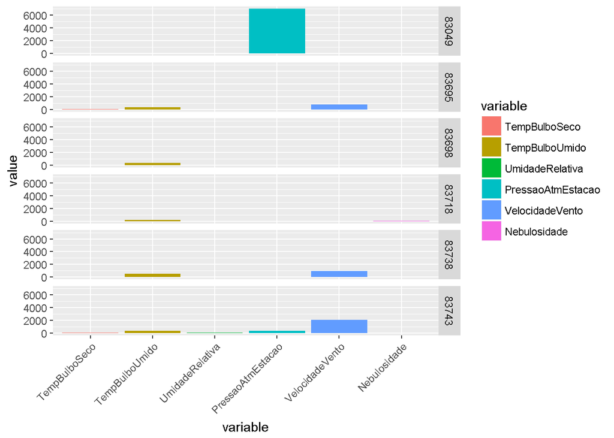

```r
meteo_rj$Estacao <- as.factor(meteo_rj$Estacao)
aggregate(. ~ Estacao, data=meteo_rj, function(x) {sum(is.na(x))}, na.action = NULL) %>%
      melt() %>%
      filter(value > 0) %>%
      ggplot(data = . , aes(variable, value, fill = variable)) +
      geom_bar(stat = "identity") + facet_grid(Estacao ~ .) +
      theme(axis.text.x = element_text(angle = 45, hjust = 1))
```

```r
paste("Valores faltantes:",
      sum(is.na(meteo_rj[meteo_rj$Estacao == 83049, "PressaoAtmEstacao"])))
```

```
  [1] "Valores faltantes: 7034"
```

```r
paste("Total de observações:", dim(meteo_rj[meteo_rj$Estacao == 83049, ])[1])
```

```
  [1] "Total de observações: 7034"
```

Podemos perceber que a estação 83049 possui todas observações para PressaoAtm vazias, desse modo, para que a análise não seja muito prejudicada, excluíremos essa coluna.

```r
meteo_rj$PressaoAtmEstacao <- NULL
names(meteo_rj)
```

```
   [1] "Estacao"         "Data"            "Hora"
   [4] "TempBulboSeco"   "TempBulboUmido"  "UmidadeRelativa"
   [7] "VelocidadeVento" "Nebulosidade"    "Latitude"
  [10] "Longitude"       "mes"             "ano"
```

```r
paste("Valores faltantes:",
      sum(is.na(meteo_rj[meteo_rj$Estacao == 83743, "VelocidadeVento"])))
```

```
  [1] "Valores faltantes: 2094"
```

```r
paste("Total de observações:", dim(meteo_rj[meteo_rj$Estacao == 83743, ])[1])
```

```
  [1] "Total de observações: 7632"
```

Podemos perceber que a estação 83743 apesar de ter um grande número de valores faltantes na coluna VelocidadeVento, a maior parte das observações está lá. Utilizaremos o pacote MICE para realizar a imputação dos dados faltantes.

#### Imputação dos valores faltantes através de imputação multivariada por equações em cascata (pacote mice)

```r
ini <- meteo_rj %>%
      select(c("TempBulboSeco", "TempBulboUmido", "VelocidadeVento",
               "UmidadeRelativa", "Nebulosidade")) %>%
      mice(data = ., maxit = 0, seed = 1869)

imp_merged <- mice.mids(ini, maxit = 3)
meteo_rj_imputado <- complete(imp_merged)
```

#### Comparando a distribuição das variáveis antes e depois da imputação.

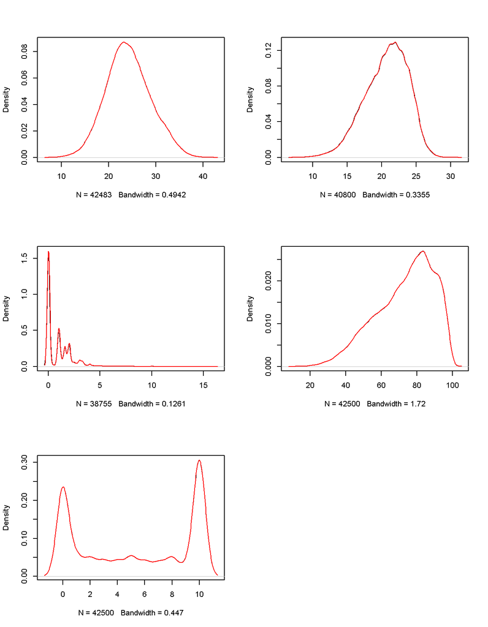

```r
# Pequena função para auxiliar na plotagem
plot.multi.dens <- function(s)
{
      junk.x = NULL
      junk.y = NULL
      for(i in 1:length(s)) {
            junk.x = c(junk.x, density(s[[i]])$x)
            junk.y = c(junk.y, density(s[[i]])$y)
      }
      xr <- range(junk.x)
      yr <- range(junk.y)
      plot(density(s[[1]]), xlim = xr, ylim = yr, main = "")
      for(i in 1:length(s)) {
            lines(density(s[[i]]), xlim = xr, ylim = yr, col = i)
      }
}

par(mfrow = c(3, 2))
for (i in names(meteo_rj_imputado)){
      plot.multi.dens(list(cc(meteo_rj[[i]]), meteo_rj_imputado[[i]]))
}
```

#### Substituindo os valores antigos pelos novos

```r
for ( i in names(meteo_rj_imputado)){
      meteo_rj[[i]] <- meteo_rj_imputado[[i]]
}
rm("meteo", "meteo_rj_imputado", freq_table)
```

### Limpeza do conjuto Focos

#### Checando a existência de valores faltantes

```r
paste("Valores faltantes:", sum(is.na(focos_rj)))
```

```
  [1] "Valores faltantes: 0"
```

#### Criando Colunas

Criando duas colunas, “mes” e “ano” para facilitar a análise.

```r
focos_rj <- focos_rj %>%
      mutate(mes = format(DataHora, "%m"),
             ano = format(DataHora, "%Y"))
rm(focos)
```

#### Checando formatos das colunas

```r
str(focos_rj)
```

```
  Classes 'tbl_df', 'tbl' and 'data.frame': 23224 obs. of  11 variables:
   $ DataHora    : POSIXct, format: "2010-01-02 16:20:00" "2010-01-04 13:14:49" ...
   $ Satelite    : Factor w/ 26 levels "AQUA-M","AQUA-T",..: 4 23 23 23 23 23 23 23 23 23 ...
   $ Municipio   : Factor w/ 6329 levels "Abadia de Goias",..: 1115 4632 263 263 3607 3607 263 263 2546 5239 ...
   $ Bioma       : Factor w/ 6 levels "Amazonia","Caatinga",..: 4 4 4 4 4 4 4 4 4 4 ...
   $ DiasSemChuva: int  5 0 0 0 0 0 0 0 0 0 ...
   $ Precipitacao: num  166.1 74.6 184.9 161.2 230.3 ...
   $ RiscoFogo   : num  0 777.7 0.2 0 777.7 ...
   $ Latitude    : num  -21.6 -22.9 -23 -23 -22.9 ...
   $ Longitude   : num  -41.3 -43.8 -44.3 -44.4 -43.1 ...
   $ mes         : chr  "01" "01" "01" "01" ...
   $ ano         : chr  "2010" "2010" "2010" "2010" ...
```

## Análise exploratória

### Focos

Distibuição das queimadas ao longo do ano, da Latitude e Longitude

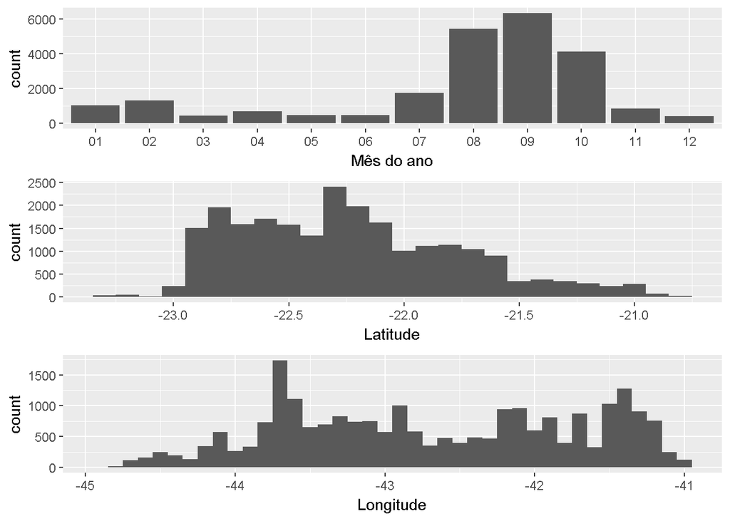

```r
# Carregando script para realizar o multiplot
source("scripts/multiplot.R")
p1 <- qplot(focos_rj$mes, xlab = "Mês do ano")
p2 <- qplot(focos_rj$Latitude, binwidth = 0.1, xlab = "Latitude")
p3 <- qplot(focos_rj$Longitude, binwidth = 0.1, xlab = "Longitude")
multiplot(p1,p2,p3)
```

Locais com maior incidência de focos de queimadas.

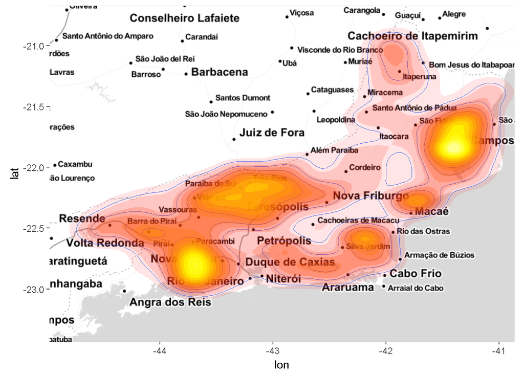

```r
BB <- c(min(focos_rj$Longitude - 0.1), min(focos_rj$Latitude - 0.1),
        max(focos_rj$Longitude + 0.1), max(focos_rj$Latitude + 0.1))
figure <- ggmap(get_map( location = BB, source = "stamen",  maptype = "toner-lite") )
figure +
      geom_density2d(data = focos_rj, aes(x = Longitude, y = Latitude), size = 0.01) +
      stat_density2d(data = focos_rj, aes(x = Longitude, y = Latitude, fill = ..level.., alpha = ..level..), size = 0.01,
    bins =16, geom = "polygon") +
      scale_fill_gradientn(colors = heat.colors(16), guide = FALSE) +
    scale_alpha(range = c(0.1, 0.8), guide = FALSE)
```

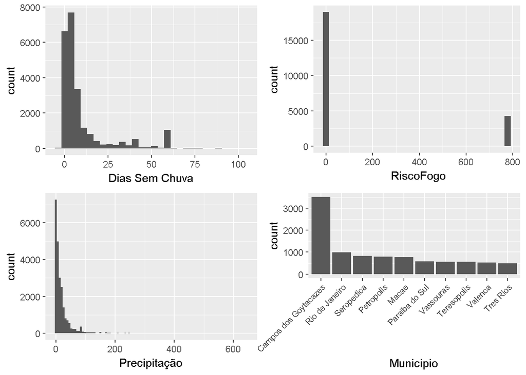

```r
p1 <- qplot(focos_rj$DiasSemChuva, xlab = "Dias Sem Chuva", bins = 30)
p2 <- qplot(focos_rj$Precipitacao, xlab = "Precipitação", bins = 100)
p3 <- qplot(focos_rj$RiscoFogo, xlab = " RiscoFogo", bins = 30)
p4 <- focos_rj %>%
  group_by(Municipio) %>%
  summarise(count = n()) %>%
  mutate(Municipio = factor(.$Municipio, levels = .$Municipio[order(-.$count)])) %>%
  top_n(10) %>%
  ggplot(data = ., aes(x = Municipio, y = count)) +
    geom_bar(stat = "identity") +
    theme_grey() + theme(axis.text.x = element_text(angle = 45, hjust = 1, size = 8))
multiplot(p1,p2,p3,p4, cols = 2)
```

De cima para baixo em sentido horário a partir da esquerda:

- Distribuição da quantidade de dias sem chuva no momento do incendio;
- Distribuição do Risco de Fogo no momento dos incêndios;
- 10 Municípios com maior quantidade de incêndios;
- Distribuição da precipitação no dia dos incêndios

### Meteo

Variação da temperatura medida com termômetro de bulbo seco ao longo do ano por estação.

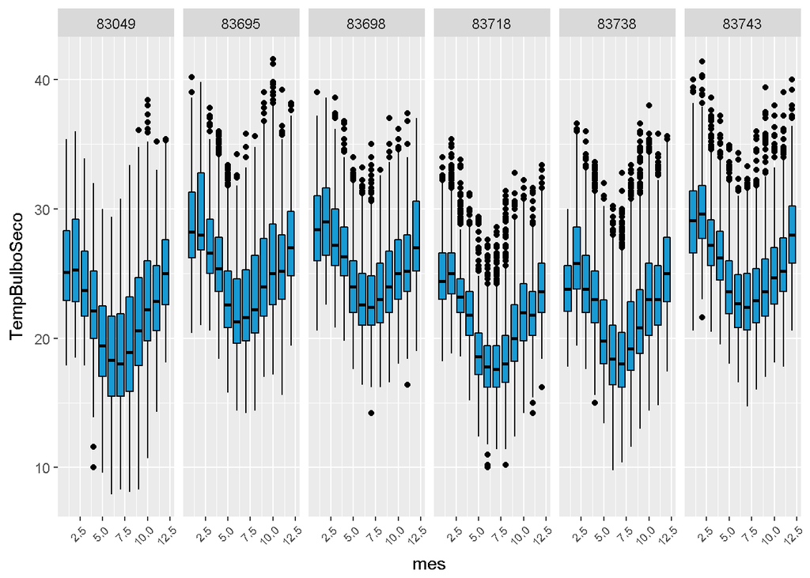

```r
ggplot(data = meteo_rj, aes(x = mes, y = TempBulboSeco, group = mes)) +
      geom_boxplot(color = "black", fill = "#189ad3") +
      facet_grid(. ~ Estacao) +
      theme_grey() + theme(axis.text.x = element_text(angle = 45, hjust = 1, size = 7))
```

Variação da temperatura medida com termômetro de bulbo úmido ao longo do ano por estação.

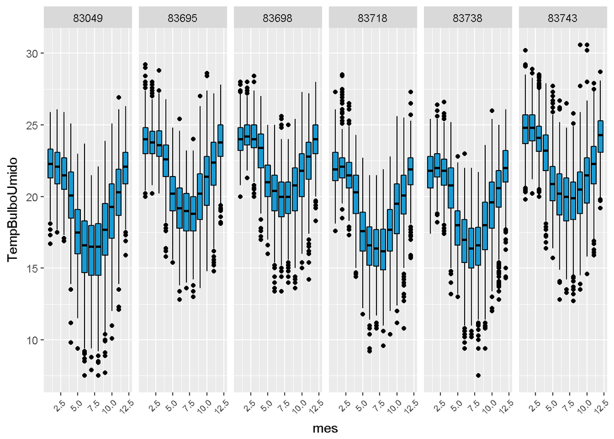

```r
ggplot(data = meteo_rj, aes(x = mes, y = TempBulboUmido, group = mes)) +
      geom_boxplot(color = "black", fill = "#189ad3") +
      facet_grid(. ~ Estacao) +
      theme_grey() + theme(axis.text.x = element_text(angle = 45, hjust = 1, size = 7))
```

Variação das diferentes tempeturas de diferentes termômetros.

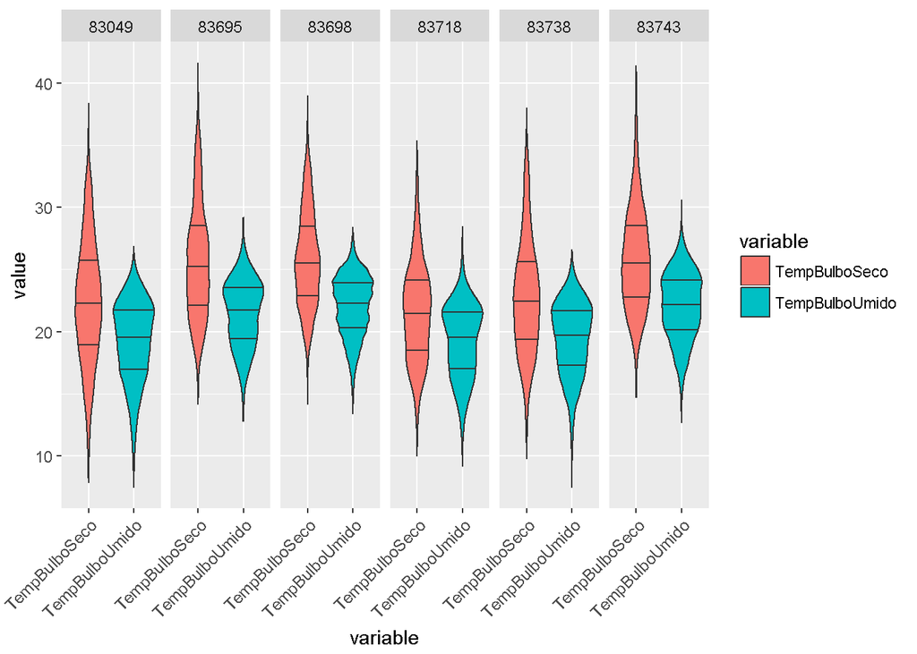

```r
ggplot(data = melt(meteo_rj[,c(1,4:5)], id.vars = "Estacao"), aes(x = variable, y = value, fill = variable)) +
      geom_violin(draw_quantiles = c(.25,.5,.75), scale = "area") +
      facet_grid(. ~ Estacao) +
      theme_grey() + theme(axis.text.x = element_text(angle = 45, hjust = 1, size = 9))
```

Variação da umidade relativa ao longo do ano por estação

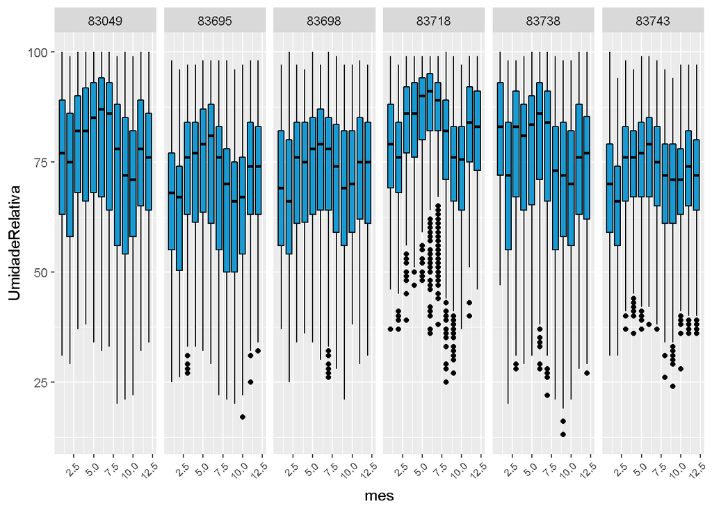

```r
ggplot(data = meteo_rj, aes(x = mes, y = UmidadeRelativa, group = mes)) +
      geom_boxplot(color = "black", fill = "#189ad3") +
      facet_grid(. ~ Estacao) +
      theme_grey() + theme(axis.text.x = element_text(angle = 45, hjust = 1, size = 7))
```

Variação da velocidade do vento ao longo do ano por estação

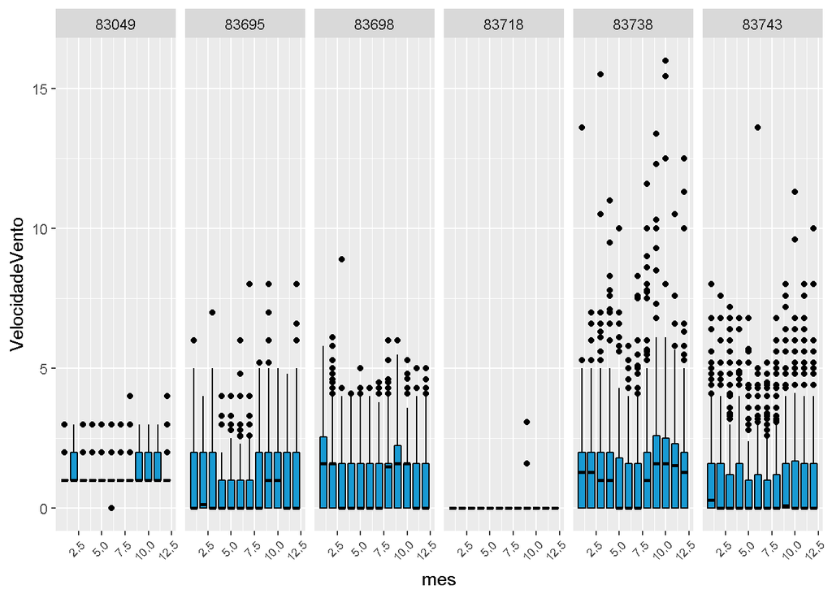

```r
ggplot(data = meteo_rj, aes(x = mes, y = VelocidadeVento, group = mes)) +
      geom_boxplot(color = "black", fill = "#189ad3") +
      facet_grid(. ~ Estacao) +
      theme_grey() + theme(axis.text.x = element_text(angle = 45, hjust = 1, size = 7))
```

Variação da nebulosidade ao longo do ano por estação

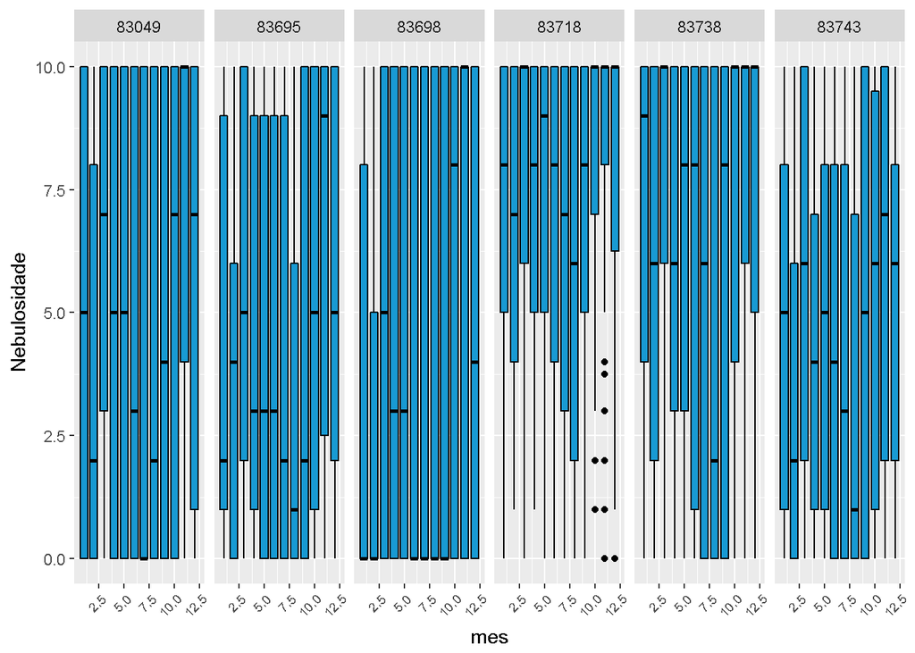

```r
ggplot(data = meteo_rj, aes(x = mes, y = Nebulosidade, group = mes)) +
      geom_boxplot(color = "black", fill = "#189ad3") +
      facet_grid(. ~ Estacao) +
      theme_grey() + theme(axis.text.x = element_text(angle = 45, hjust = 1, size = 7))
```

Localização das estações meteorológicas

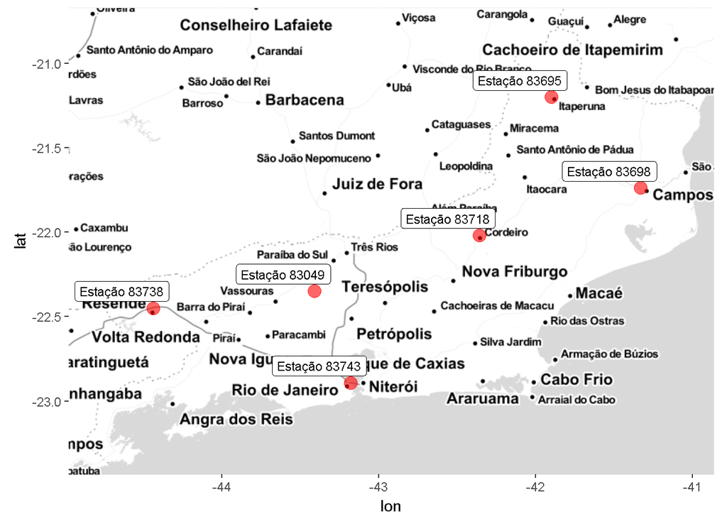

```r
estacoes = unique(meteo_rj[,c(1, 9, 10)])
figure2 <- ggmap(get_map( location = BB, source = "stamen",  maptype = "toner-lite") )
figure2 +
  geom_point(data = estacoes, aes(x= Longitude, y = Latitude), color = "red", size = 4, alpha = 0.6) +
  geom_label(data = estacoes, aes(label = paste("Estação", Estacao), x = Longitude, y = Latitude),
             nudge_x = -0.2, nudge_y = 0.1, size = 3)
```

Matriz de Correlação das Variáveis

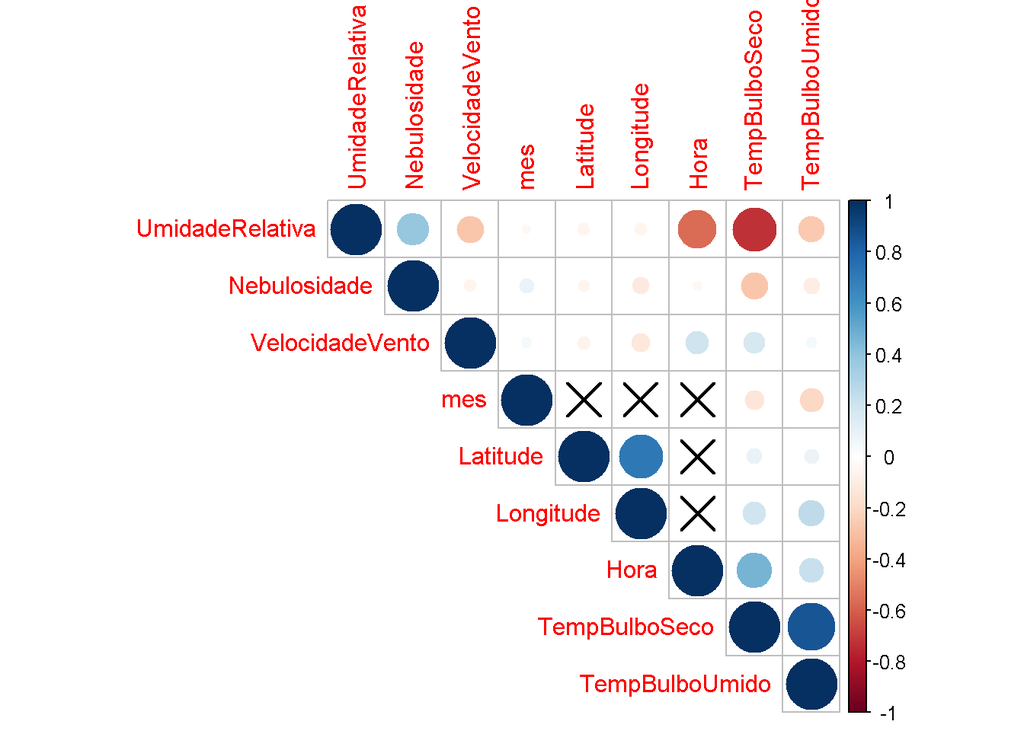

```r
res <- rcorr(as.matrix(meteo_rj[,3:11]))
corrplot(res$r,
         type = "upper",
         order="hclust",
         p.mat = res$P,
         sig.level = 0.01,
         insig = "pch")
```

## Agregação

Realizaremos as agregação dos dados por dia para agilizar o processamento dos dados.

```r
antes <- nrow(meteo_rj)
# Transformanddo em data.table para maior agilidade
meteo_rj <- setDT(meteo_rj)
# Retirando algumas colunas e agregando os dados por dia, utilizando a média do dia.
meteo_rj <- meteo_rj[,-c("Hora", "mes", "ano"), with = FALSE
                          ][, lapply(.SD, mean), by = .(Data, Estacao)]
depois <- nrow(meteo_rj)

sprintf("Redução de %.2f%% após a agregação do dataset.", (depois/antes)*100)
```

```
  [1] "Redução de 35.18% após a agregação do dataset."
```

## Integração dos Dataframes

O objetivo da integração dos dataframes é reunir em um único dataframe as informações meteorológicas e de focos de incêndio, para cada dia . A integração dos dois Dataframes será realizada de acordo com o seguinte fluxo:

1. Calcular o raio de alcance de cada estação meteorológica, ou seja, calcular a distância entre cada estação e a estação mais próxima a ela e dividir essa distância por dois.
2. Para cada registro do dataframe meteo:
   - Selecionar todos os focos do dataframe focos que ocorreram no dia do registro;
   - Calcular a distância entre a estação e todos os focos e verificar se eles estão dentro do raio de alcance da estação.
   - Caso positivo, registrar o número de focos em uma nova coluna (n_focos)
   - Caso negativo, registrar 0 focos em uma nova coluna (n_focos)
3. Será criada uma nova coluna “incendio” e caso o registro tenha pelo menos 1 foco, essa coluna receberá “sim”, caso contrário, “nao”.

```r
# Função principal
juncao <- function(df_focos, df_meteo=df_meteo, dt_estacoes = NULL){
      if (is.null(dt_estacoes)){
            dt_estacoes <- cria_estacoes(df_meteo)
      }
      dt_meteo <- setDT(df_meteo)
      dt_focos <- setDT(df_focos)
      dt_focos <- df_focos[,DataHora := as.IDate(DataHora)]
      for (i in 1:nrow(dt_meteo)){
            # para cada obs_meteo calcular se tem um foco dentro do raio da
            # estacão no dia
            obs_meteo <- dt_meteo[i]
            fdia <- focos_no_dia(obs_meteo, dt_focos)
            if (nrow(fdia) > 0){
                  n_focos <- checa_dist(obs_meteo, fdia, dt_estacoes)
            } else {
                  n_focos <- 0
            }
            dt_meteo[i, "n_focos"] <- n_focos
      }
return(dt_meteo)
}
# Cria tabela das estações e seus raios de ação
cria_estacoes <- function(df_meteo){
      dt_estacoes <- setDT(df_meteo[,c("Estacao", "Longitude", "Latitude")])
      dt_estacoes <- unique(dt_estacoes)
      for (i in 1:nrow(dt_estacoes)){
            dt_estacoes[i,"Raio"] <- cria_raio_estacao(dt_estacoes[i,2:3,
                                                                  with = FALSE],
                                                       dt_estacoes)
      }
      dt_estacoes <- dt_estacoes[,lapply(.SD, mean), by = .(Estacao)]
      setkey(dt_estacoes, Estacao)
      return(dt_estacoes)
}
# Calcula os raios
cria_raio_estacao <- function(ponto, dt_estacoes){
      matriz <- setattr(as.data.frame(distm(ponto, as.matrix(dt_estacoes[,2:3,
                                                                with = FALSE])),
                                      stringsAsFactors=FALSE),
                        "class", "data.table")
      matriz <- matriz[,matriz > 100, with = FALSE]
      idx <- which.min(matriz)
      return(as.numeric(matriz[,..idx])/2)
}
# Separa o focos do referido dia
focos_no_dia <- function(obs_meteo, dt_focos){
      dia <- obs_meteo[,Data]
      return(dt_focos[DataHora == as.IDate(format(dia, "%Y-%m-%d"))])
}
# Calcula a distância e confere se está dentro do raio de ação
checa_dist <- function(obs_meteo, dt_focos, dt_estacoes){
      # extrai número estacao
      estacao <- obs_meteo[,Estacao]
      # checa em estacoes pelas coordenadas da estacao
      coord_estacao <- dt_estacoes[Estacao == estacao,
                                   c("Longitude", "Latitude"),
                                   with= FALSE]
      # checa em estacoes pelo raio da estacao
      raio_estacao <- dt_estacoes[Estacao == estacao, Raio]
      # calcula distancias entre todos os focos e a estacao
      matriz <- setattr(
            as.data.frame(distm(coord_estacao,
                                as.matrix(dt_focos[,c("Longitude", "Latitude"),
                                                   with = FALSE])),
                                      stringsAsFactors=FALSE), "class",
                        "data.table")
      # verifica se existem focos dentro do raio
      n_focos <- sum(matriz <= raio_estacao)
      # caso positivo retorna o número de focos
      return(n_focos)
}

dt_estacoes <- cria_estacoes(meteo_rj)
dt_final <- juncao(focos_rj, meteo_rj, dt_estacoes)
```

```r
# Recriando as colunas mes e ano
dt_final[, c("mes", "ano") := list(as.numeric(format(Data, "%m")),
                                   as.numeric(format(Data, "%Y")))]
```

Criando a coluna Incêndio:

```r
dt_final[, "incendio" := ifelse(n_focos > 0, "sim", "nao")]
dt_final$incendio <- as.factor(dt_final$incendio)
```

Dataset final:

```r
head(dt_final)
```

| Data | Estacao | TempBulboSeco | TempBulboUmido | UmidadeRelativa | VelocidadeVento | Nebulosidade | Latitude | Longitude | n_focos | mes | ano | incendio |
| --- | --- | --- | --- | --- | --- | --- | --- | --- | --- | --- | --- | --- |
| 2010-01-01 | 83049 | 25.00000 | 22.43333 | 80.66667 | 1.000000 | 8.333333 | -22.35 | -43.41 | 0 | 1 | 2010 | nao |
| 2010-01-02 | 83049 | 26.56667 | 22.36667 | 71.00000 | 1.333333 | 3.333333 | -22.35 | -43.41 | 0 | 1 | 2010 | nao |
| 2010-01-03 | 83049 | 26.90000 | 21.70000 | 65.66667 | 1.333333 | 0.000000 | -22.35 | -43.41 | 0 | 1 | 2010 | nao |
| 2010-01-04 | 83049 | 26.80000 | 22.50000 | 71.33333 | 1.000000 | 2.333333 | -22.35 | -43.41 | 0 | 1 | 2010 | nao |
| 2010-01-05 | 83049 | 27.50000 | 23.43333 | 71.33333 | 1.000000 | 5.000000 | -22.35 | -43.41 | 0 | 1 | 2010 | nao |
| 2010-01-06 | 83049 | 25.36667 | 22.43333 | 78.33333 | 1.000000 | 6.666667 | -22.35 | -43.41 | 0 | 1 | 2010 | nao |

```r
tail(dt_final)
```

| Data | Estacao | TempBulboSeco | TempBulboUmido | UmidadeRelativa | VelocidadeVento | Nebulosidade | Latitude | Longitude | n_focos | mes | ano | incendio |
| --- | --- | --- | --- | --- | --- | --- | --- | --- | --- | --- | --- | --- |
| 2016-12-26 | 83743 | 28.70 | 24.40 | 74.5 | 1.00 | 1.875 | -22.89 | -43.18 | 0 | 12 | 2016 | nao |
| 2016-12-27 | 83743 | 31.45 | 26.75 | 78.0 | 1.30 | 3.750 | -22.89 | -43.18 | 0 | 12 | 2016 | nao |
| 2016-12-28 | 83743 | 33.65 | 26.95 | 62.5 | 0.50 | 1.250 | -22.89 | -43.18 | 0 | 12 | 2016 | nao |
| 2016-12-29 | 83743 | 31.55 | 25.95 | 71.5 | 1.00 | 4.375 | -22.89 | -43.18 | 0 | 12 | 2016 | nao |
| 2016-12-30 | 83743 | 30.85 | 26.10 | 71.0 | 1.50 | 0.000 | -22.89 | -43.18 | 0 | 12 | 2016 | nao |
| 2016-12-31 | 83743 | 27.35 | 24.90 | 81.5 | 1.05 | 3.750 | -22.89 | -43.18 | 0 | 12 | 2016 | nao |

```r
str(dt_final)
```

```
  Classes 'data.table' and 'data.frame':    14968 obs. of  13 variables:
   $ Data           : Date, format: "2010-01-01" "2010-01-02" ...
   $ Estacao        : Factor w/ 6 levels "83049","83695",..: 1 1 1 1 1 1 1 1 1 1 ...
   $ TempBulboSeco  : num  25 26.6 26.9 26.8 27.5 ...
   $ TempBulboUmido : num  22.4 22.4 21.7 22.5 23.4 ...
   $ UmidadeRelativa: num  80.7 71 65.7 71.3 71.3 ...
   $ VelocidadeVento: num  1 1.33 1.33 1 1 ...
   $ Nebulosidade   : num  8.33 3.33 0 2.33 5 ...
   $ Latitude       : num  -22.4 -22.4 -22.4 -22.4 -22.4 ...
   $ Longitude      : num  -43.4 -43.4 -43.4 -43.4 -43.4 ...
   $ n_focos        : num  0 0 0 0 0 0 0 0 0 0 ...
   $ mes            : num  1 1 1 1 1 1 1 1 1 1 ...
   $ ano            : num  2010 2010 2010 2010 2010 2010 2010 2010 2010 2010 ...
   $ incendio       : Factor w/ 2 levels "nao","sim": 1 1 1 1 1 1 1 1 1 1 ...
   - attr(*, ".internal.selfref")=<externalptr>
```

```r
summary(dt_final)
```

```
        Data             Estacao     TempBulboSeco   TempBulboUmido
   Min.   :2010-01-01   83049:2348   Min.   :11.70   Min.   : 9.70
   1st Qu.:2011-09-19   83695:2557   1st Qu.:21.47   1st Qu.:18.53
   Median :2013-06-14   83698:2557   Median :24.13   Median :20.96
   Mean   :2013-06-20   83718:2413   Mean   :24.04   Mean   :20.60
   3rd Qu.:2015-03-19   83738:2537   3rd Qu.:26.67   3rd Qu.:22.83
   Max.   :2016-12-31   83743:2556   Max.   :36.20   Max.   :28.07
   UmidadeRelativa VelocidadeVento   Nebulosidade       Latitude
   Min.   :36.67   Min.   :0.0000   Min.   : 0.000   Min.   :-22.89
   1st Qu.:67.00   1st Qu.:0.0000   1st Qu.: 2.333   1st Qu.:-22.45
   Median :74.00   Median :0.8667   Median : 5.667   Median :-22.02
   Mean   :73.76   Mean   :0.8679   Mean   : 5.396   Mean   :-22.11
   3rd Qu.:80.67   3rd Qu.:1.3333   3rd Qu.: 8.667   3rd Qu.:-21.74
   Max.   :98.67   Max.   :7.6000   Max.   :10.000   Max.   :-21.20
     Longitude         n_focos              mes              ano
   Min.   :-44.44   Min.   :  0.0000   Min.   : 1.000   Min.   :2010
   1st Qu.:-43.41   1st Qu.:  0.0000   1st Qu.: 3.000   1st Qu.:2011
   Median :-42.36   Median :  0.0000   Median : 6.000   Median :2013
   Mean   :-42.76   Mean   :  0.8537   Mean   : 6.483   Mean   :2013
   3rd Qu.:-41.90   3rd Qu.:  0.0000   3rd Qu.: 9.000   3rd Qu.:2015
   Max.   :-41.33   Max.   :180.0000   Max.   :12.000   Max.   :2016
   incendio
   nao:12443
   sim: 2525
```

# Mineração de dados

## Escolha do algoritmo

Para escolhermos o melhor algoritmo a ser utilizado, devemos levar em conta a acurácia do modelo e o tempo necessário para o seu treinamento, pois conforme novas observações forem sendo obtidas e a massa de dados for crescendo o tempo necessário para o treinamento do modelo poderá se tornar algo inexequível e pouco prático.

## Balanceamento das classes

A coluna incendio será a nossa coluna alvo. Desde já, podemos percerber que as classes da nossa coluna alvo está desbalanceada o que poderá interferir na mineração de dados, pois criará um viés a favor da classe que possui mais observações.

Desse modo, podemos empregar técnicas para balanceamento de classes, como over-sampling e under-sampling.

```r
n_sim <- table(dt_final$incendio)[2]
idx_nao <- which(dt_final$incendio == "nao")
idx_sim <- which(dt_final$incendio == "sim")
idx <- idx_nao[sample(length(idx_nao), n_sim)]
dt_nao <- dt_final[idx]
dt_sim <- dt_final[idx_sim]
dt_balanceado <- rbind(dt_sim, dt_nao)
```

Separando em dois datasets, um para treino e outro para testes

```r
idx <- createDataPartition(dt_balanceado$incendio, p = .75, list = FALSE)
treino <- dt_balanceado[idx,]
teste <- dt_balanceado[-idx,]
```

Configurando o método de treino do algoritmo, a função utilizará a validação cruzada com kfold = 10 para escolher os melhores parâmetros automaticamente.

```r
control <- trainControl(method="cv",
                        number = 10,
                        savePredictions="final", classProbs = T)
```

Fórmula a ser utilizada, ou seja as variáveis preditoras e a variável predita.

```r
form <- as.formula("incendio ~ Data+TempBulboSeco+TempBulboUmido+
                         UmidadeRelativa+VelocidadeVento+
                         Nebulosidade+Latitude+Longitude+mes")
```

```r
set.seed(1869)
metric <- "Accuracy"
tuning <-  expand.grid(interaction.depth = c(3, 6, 9),
                          n.trees = c(100, 250),
                          shrinkage = .1,
                          n.minobsinnode = c(10, 20, 30))
fit <- train(form, data = treino,
                 trControl = control, method = "rf",
                 metric = metric)
```

Resultados de diferentes parametrizações:

```
  Random Forest

  3788 samples
     9 predictor
     2 classes: 'nao', 'sim'

  No pre-processing
  Resampling: Cross-Validated (10 fold)
  Summary of sample sizes: 3409, 3409, 3410, 3408, 3408, 3410, ...
  Resampling results across tuning parameters:

    mtry  Accuracy   Kappa
    2     0.7753620  0.5507230
    5     0.7714020  0.5427973
    9     0.7695565  0.5391131

  Accuracy was used to select the optimal model using the largest value.
  The final value used for the model was mtry = 2.
```

# **Interpretação e Avaliação**

O seguinte gráfico mostra o a acurácia em relação aos diferentes parâmetros utilizados durante o ajuste.

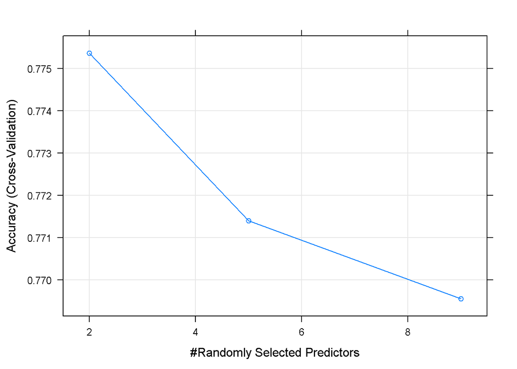

```r
plot(fit)
```

Gráfico mostrando a importância de cada variável para a predição.

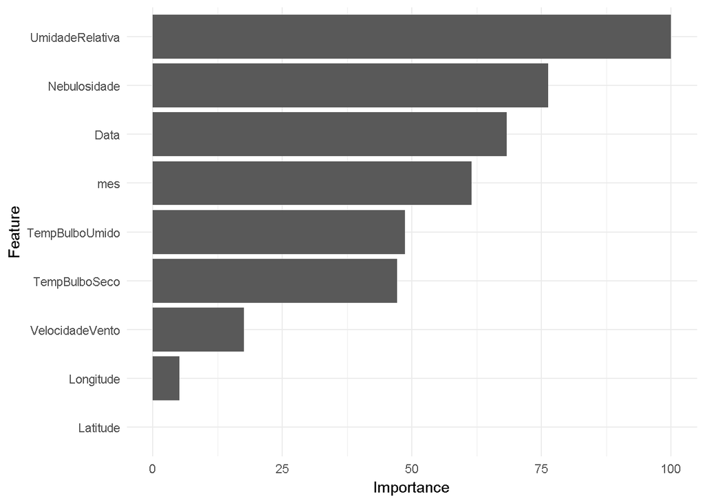

```r
ggplot(varImp(fit)) + theme_minimal()
```

A partir desse modelo final vamos testar com o dataset “teste” que foi separado no início da análise.

```r
pred <- predict(fit, teste)
mat_conf <- confusionMatrix(pred, reference = teste$incendio,
                             positive = "sim")
mat_conf
```

```
  Confusion Matrix and Statistics

            Reference
  Prediction nao sim
         nao 484 136
         sim 147 495

                 Accuracy : 0.7758
                   95% CI : (0.7517, 0.7985)
      No Information Rate : 0.5
      P-Value [Acc > NIR] : <2e-16

                    Kappa : 0.5515
   Mcnemar's Test P-Value : 0.5522

              Sensitivity : 0.7845
              Specificity : 0.7670
           Pos Pred Value : 0.7710
           Neg Pred Value : 0.7806
               Prevalence : 0.5000
           Detection Rate : 0.3922
     Detection Prevalence : 0.5087
        Balanced Accuracy : 0.7758

         'Positive' Class : sim
```

De acordo com a matriz de confusão:

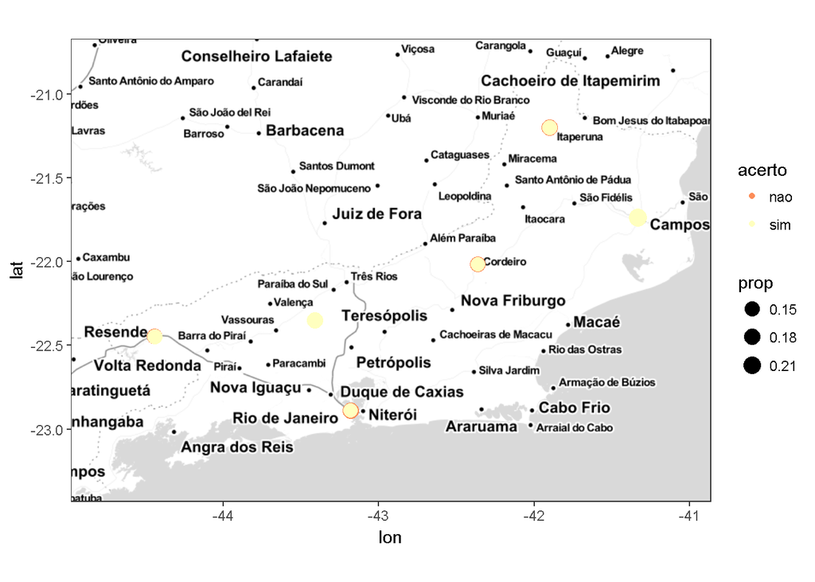

```r
figure2+
      geom_count(data = cbind(teste, pred)[,acerto := ifelse(incendio==pred, "sim", "nao")],
       aes(x=Longitude, y=Latitude, color = acerto, size = ..prop..), show.legend = T) +
      scale_size_area(max_size = 5) + theme_bw() +
      scale_color_brewer(type = "div",direction = 1, palette = "Spectral")
```

```r
data.table(cbind(teste, pred)[,acerto := ifelse(incendio==pred, "sim", "nao")])
```

| Data | Estacao | TempBulboSeco | TempBulboUmido | UmidadeRelativa | VelocidadeVento | Nebulosidade | Latitude | Longitude | n_focos | mes | ano | incendio | pred | acerto |
| --- | --- | --- | --- | --- | --- | --- | --- | --- | --- | --- | --- | --- | --- | --- |
| 2010-06-16 | 83049 | 15.80000 | 13.10000 | 78.66667 | 1.00000000 | 0.0000000 | -22.35 | -43.41 | 1 | 6 | 2010 | sim | nao | nao |
| 2010-07-22 | 83049 | 21.10000 | 16.50000 | 64.33333 | 1.33333333 | 0.0000000 | -22.35 | -43.41 | 1 | 7 | 2010 | sim | sim | sim |
| 2010-07-27 | 83049 | 17.40000 | 15.10000 | 79.66667 | 1.00000000 | 1.3333333 | -22.35 | -43.41 | 2 | 7 | 2010 | sim | sim | sim |
| 2010-08-08 | 83049 | 18.53333 | 14.93333 | 72.00000 | 1.00000000 | 0.0000000 | -22.35 | -43.41 | 3 | 8 | 2010 | sim | sim | sim |
| 2010-08-09 | 83049 | 18.40000 | 15.96667 | 78.66667 | 1.00000000 | 0.6666667 | -22.35 | -43.41 | 3 | 8 | 2010 | sim | sim | sim |
| 2010-08-10 | 83049 | 19.30000 | 16.46667 | 73.66667 | 1.00000000 | 2.3333333 | -22.35 | -43.41 | 1 | 8 | 2010 | sim | sim | sim |
| 2010-08-25 | 83049 | 22.40000 | 16.10000 | 56.33333 | 1.00000000 | 0.0000000 | -22.35 | -43.41 | 7 | 8 | 2010 | sim | sim | sim |
| 2010-08-28 | 83049 | 21.76667 | 17.16667 | 70.66667 | 1.00000000 | 2.3333333 | -22.35 | -43.41 | 11 | 8 | 2010 | sim | sim | sim |
| 2010-08-29 | 83049 | 22.90000 | 17.90000 | 64.66667 | 1.33333333 | 0.0000000 | -22.35 | -43.41 | 1 | 8 | 2010 | sim | sim | sim |
| 2010-08-30 | 83049 | 21.66667 | 17.70000 | 68.33333 | 1.00000000 | 0.0000000 | -22.35 | -43.41 | 5 | 8 | 2010 | sim | sim | sim |

[output cut: 1252 more lines]